# Analysis of FASD Case/Control data; only CHR1 is used for faster computation

# Comparing FASD and healthy CpG spots

5 most significant positions. Colored by disease status

## cg12406683

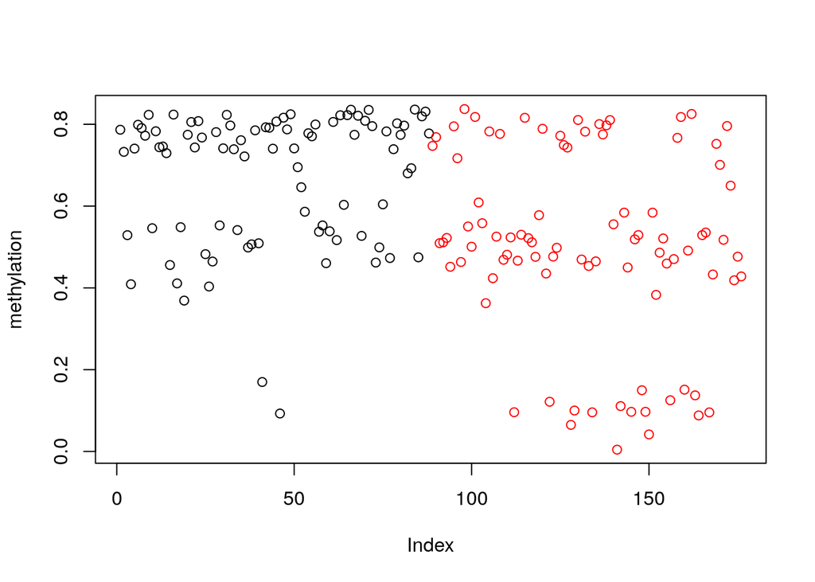

## cg21805734

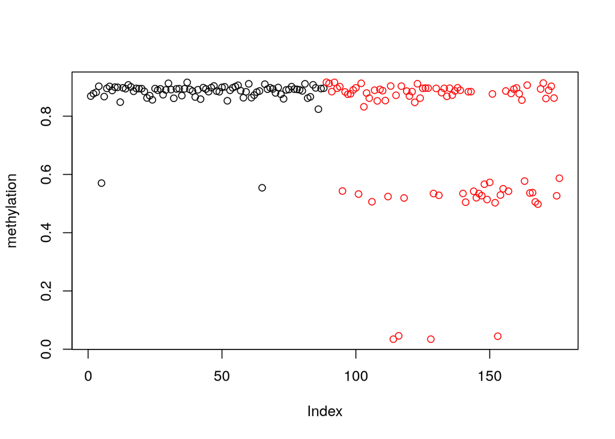

## cg24849049

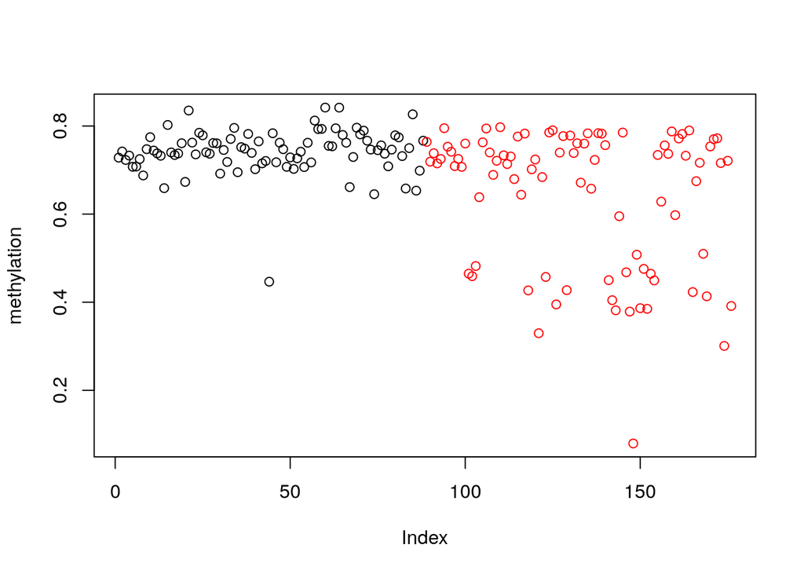

## cg13919631

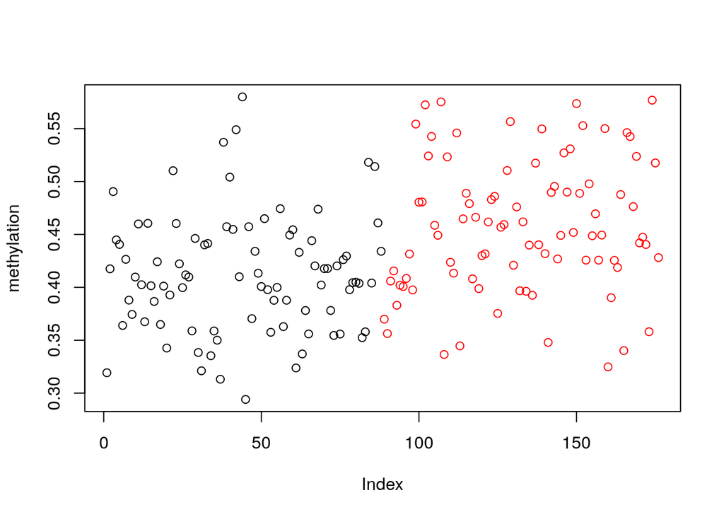

## cg22010140

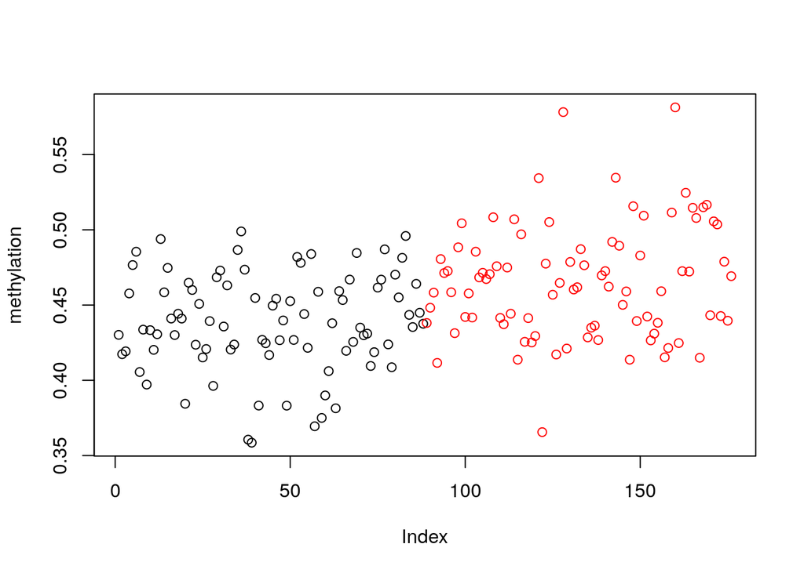

# P value table

| Significance | No..of.genes |
| --- | --- |
| Total | 46101 |
| α = 0.1 | 5178 |
| α = 0.05 | 2916 |
| α = 0.01 | 837 |
| FDR = 0.05 | 11 |
| Bonf = 0.05 | 5 |

# P value histogram

This is also reflected in the low number of significant probes left after FDR and Bonferroni corrections.

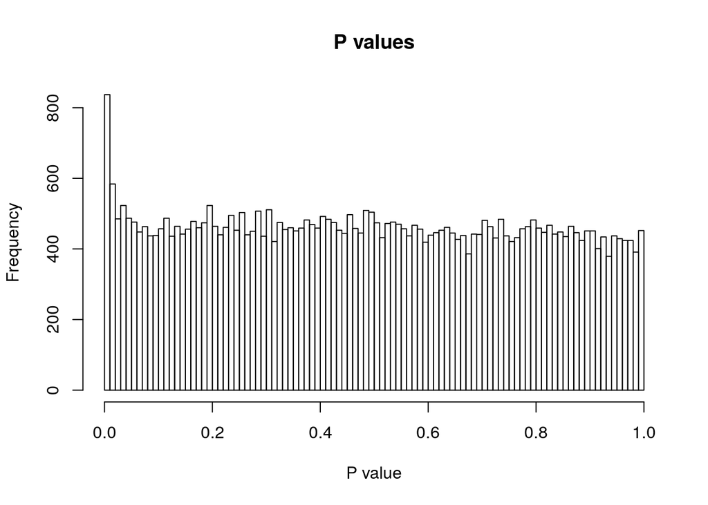

# Volcano plot

Red line marks the p value of 0.05 and the yellow one is the threshold of significance after Bonferroni correction.

The symmetry along $x=0$ axis shows that neither cases nor controls have more probes that have lower or higher mean methylation values.

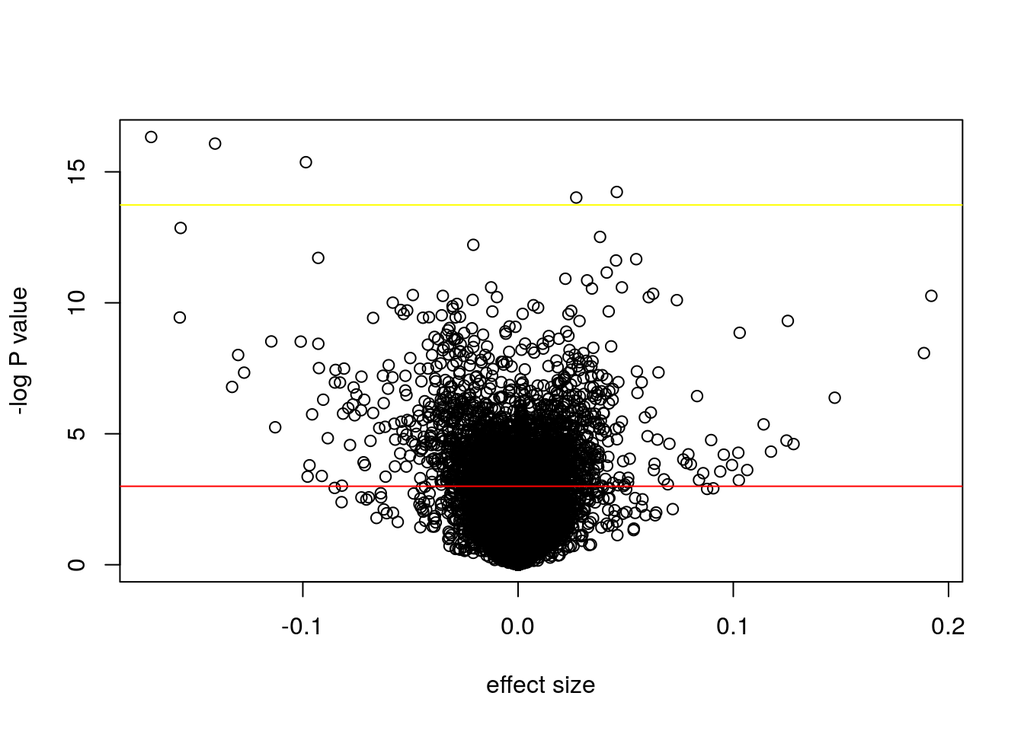

# Manhattan plot

The distribution of $-log(P)$ values in the 1st chromosome.

The density plot shows that the bumps of significant probes are caused by high density of probes in certain intervals of the chromosome and are to be expected.

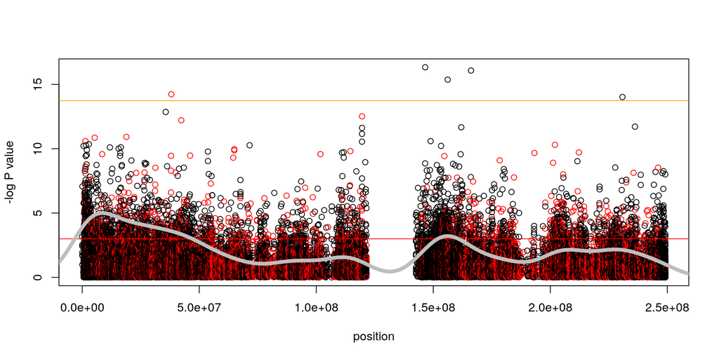

# CpGs that correlate with age

5 most significant positions.

## cg16909962

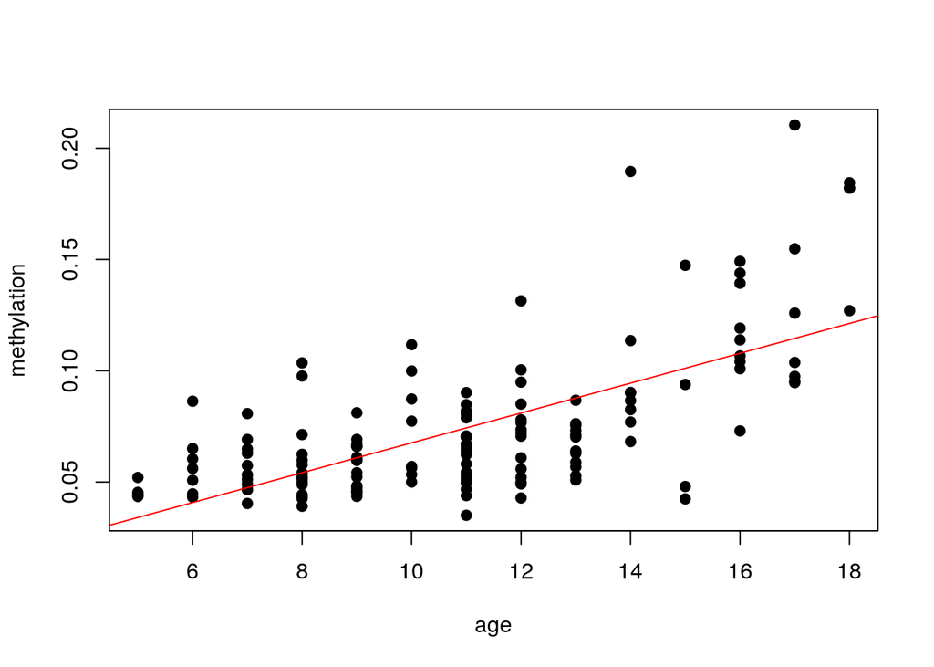

## cg15358431

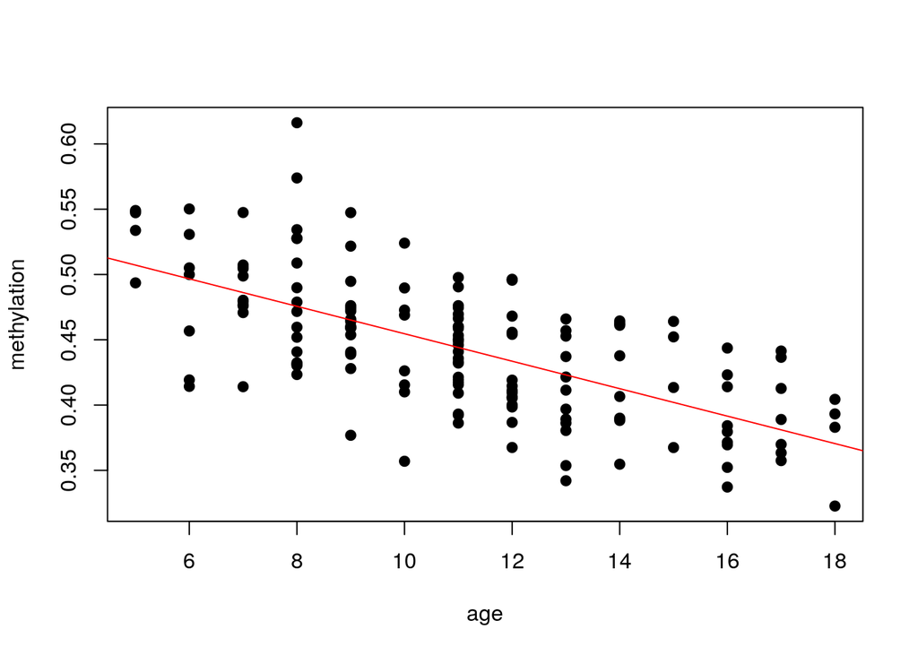

## cg06335143

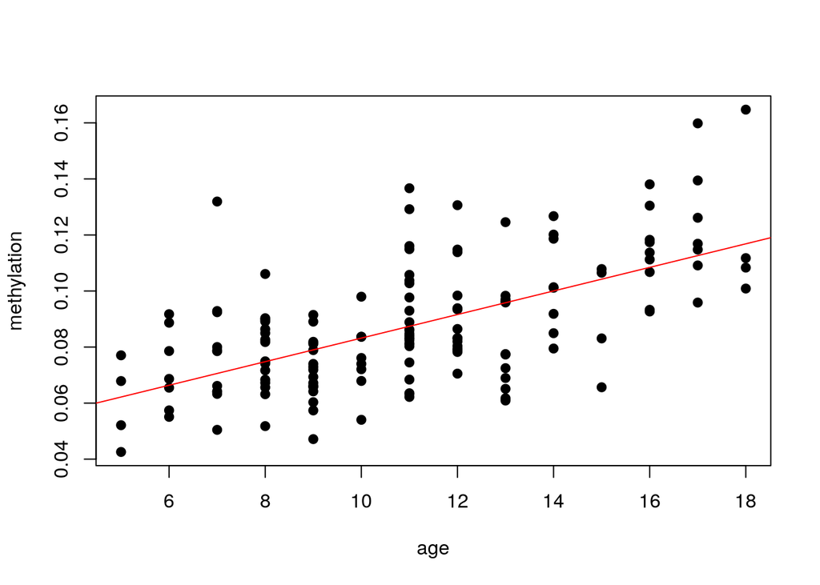

## cg20308540

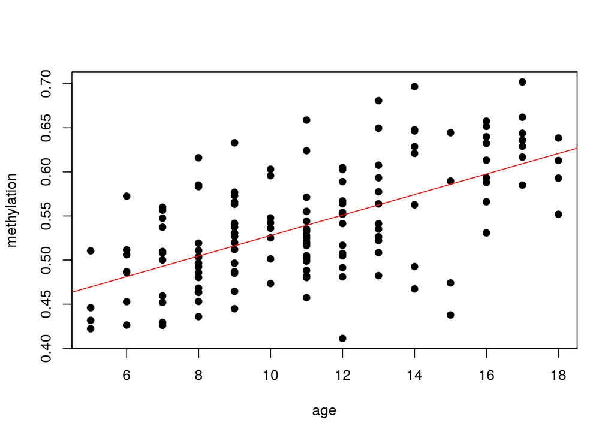

## cg16894746

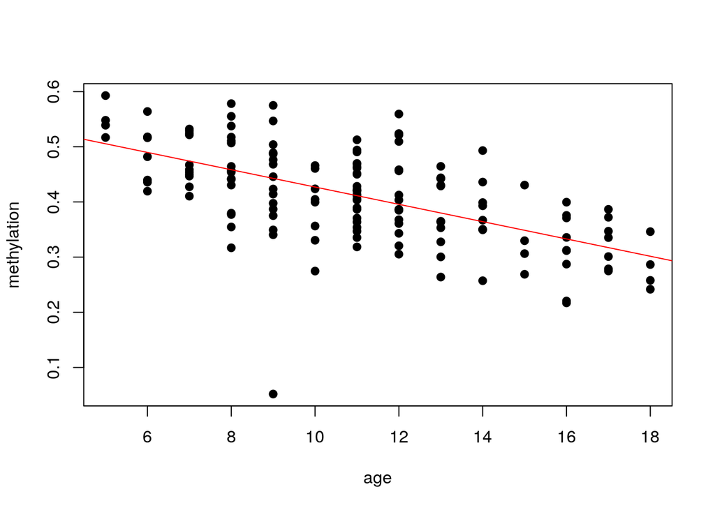

# P value table

| Significance | No..of.genes |
| --- | --- |
| Total | 46101 |
| α = 0.1 | 12174 |
| α = 0.05 | 8111 |
| α = 0.01 | 3398 |
| FDR = 0.05 | 1579 |
| Bonf = 0.05 | 187 |

# P value histogram

The number of discoveries is higher than before, it can also be seen in the P value histogram which has a higher proportion of probes with small P values.

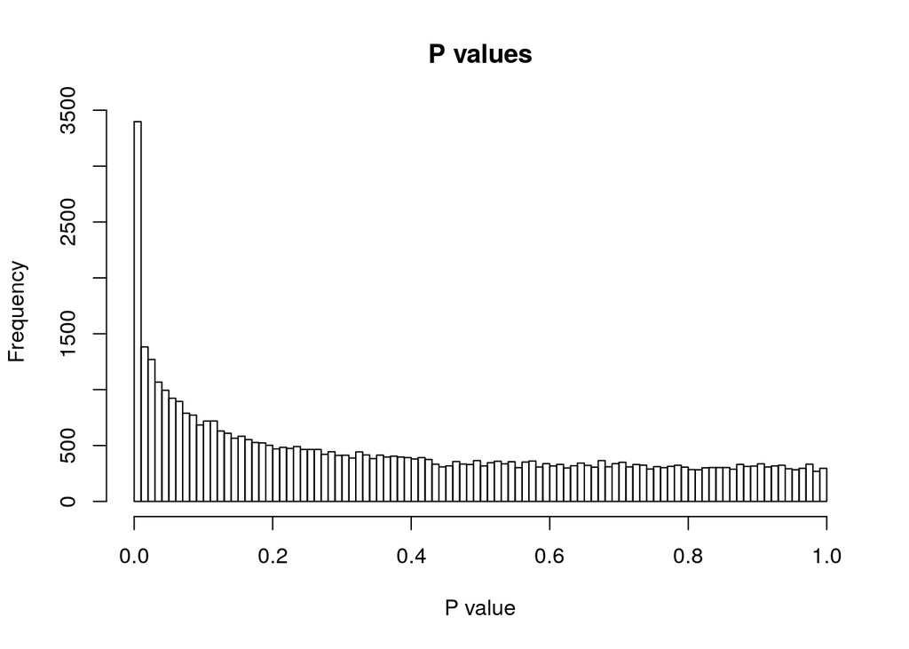

# Volcano plot

Red and yellow lines are the same as before.

This plot is not as symmetrical as the previous one, it is slightly skewed to the left. This means that there are more values with negative effect size. However, if we look only at data left after Bonferroni correction, there are more CpGs that increase in methylation with age.

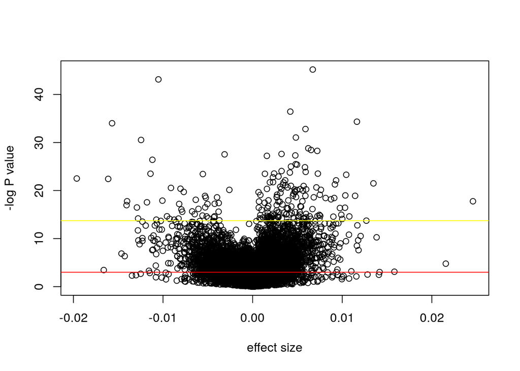

# Manhattan plot

Similar graph as before, just with the Bonferroni threshold line ‘lower’. In this plot some spikes of highly significant probes are more evident and are not captured by the density plot (e.g. peaks around position $10^8$) which suggests that some regions in the chromosome have a higher proportion of significant probes.

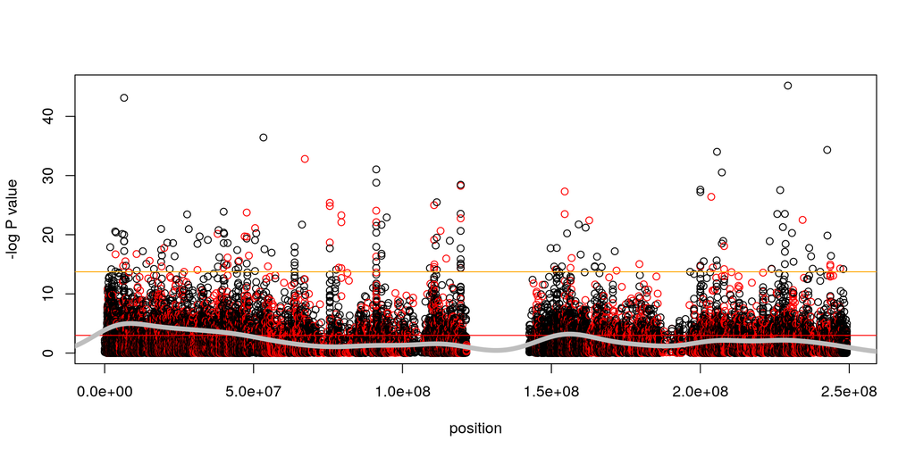